# IE360 Homework 2

## Model 3 - Adding regressors to the model

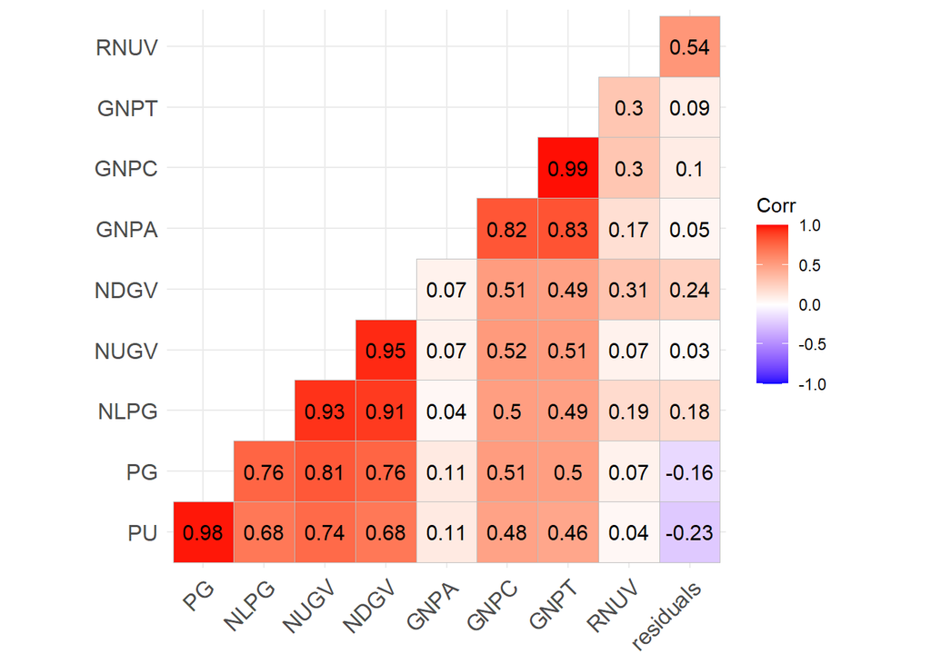

```r
# correlation variables
res_table <- data.table()
res_table <- data[,3:11]
res_table[,residuals := c(Model2$residuals, rep(NA,4))]


correl_info=cor(res_table[1:28])

ggcorrplot(correl_info,
           hc.order = TRUE,
           type = "lower",
           lab = TRUE)
```

By using the residuals of model2 (model with trend and seasonality), I look at the correlation between residuals and the independent variables given. As a result, I realize that the RNUV has the highest correlation with residuals.

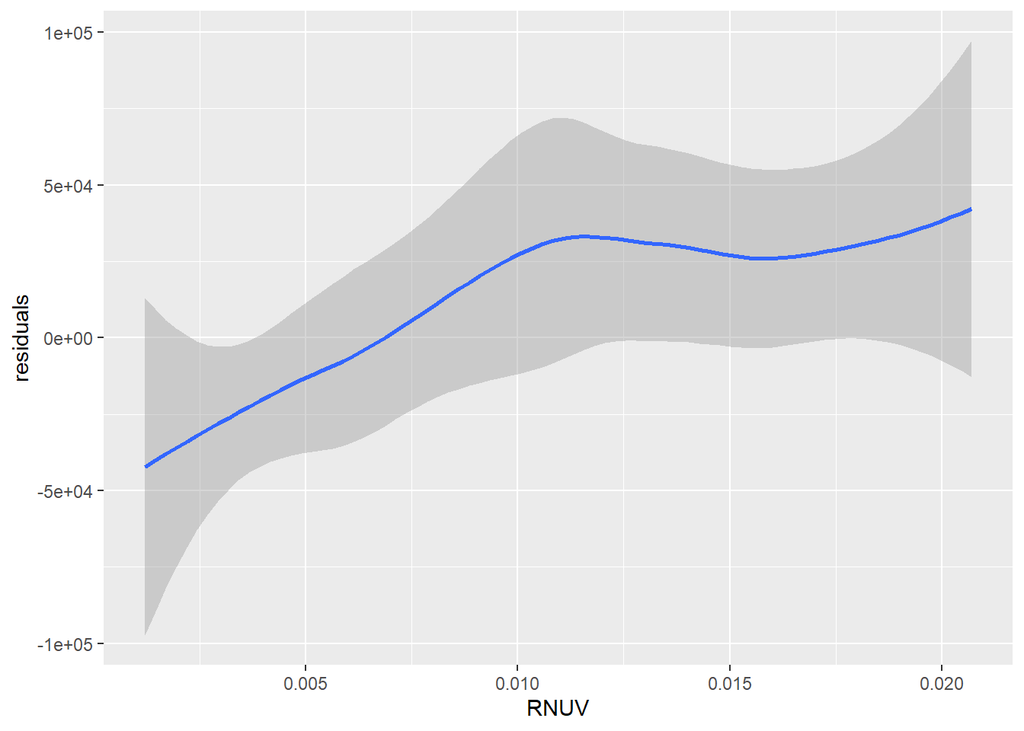

```r
ggplot(res_table,aes(x=RNUV, y=residuals)) + geom_smooth()
```

```r
# Model with RNUV, trend, QuarterFactor(seasonality component)
Model3 <- lm(UGS ~ trend + QuarterFactor + RNUV, data)
summary(Model3)
```

```
##
## Call:
## lm(formula = UGS ~ trend + QuarterFactor + RNUV, data = data)
##
## Residuals:
##    Min     1Q Median     3Q    Max
## -63228 -15846  -4663  27458  83717
##
## Coefficients:
##                 Estimate Std. Error t value Pr(>|t|)
## (Intercept)    1033325.5    21474.4  48.119  < 2e-16 ***
## trend           -13358.7      962.6 -13.878 2.32e-12 ***
## QuarterFactor2  106875.8    22235.6   4.807 8.43e-05 ***
## QuarterFactor3  257217.4    22410.8  11.477 9.30e-11 ***
## QuarterFactor4   69194.5    23325.1   2.967  0.00713 **
## RNUV           4496731.4  1372135.5   3.277  0.00344 **
## ---
## Signif. codes:  0 '***' 0.001 '**' 0.01 '*' 0.05 '.' 0.1 ' ' 1
##
## Residual standard error: 40710 on 22 degrees of freedom
##   (4 observations deleted due to missingness)
## Multiple R-squared:  0.9408, Adjusted R-squared:  0.9274
## F-statistic: 69.94 on 5 and 22 DF,  p-value: 9.264e-13
```

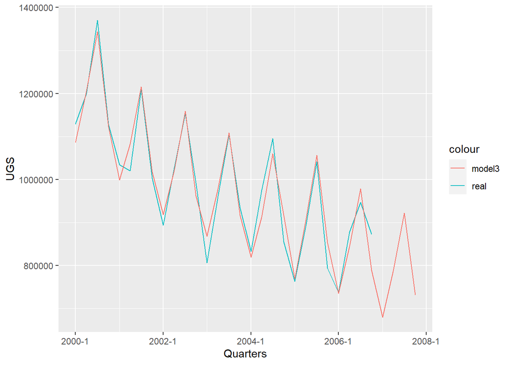

```r
data[,pred_model3 := predict(Model3,data)]
ggplot(data,aes(x=Quarters)) + geom_line(aes(y=UGS, color="real")) + geom_line(aes(y=pred_model3, color="model3"))
```

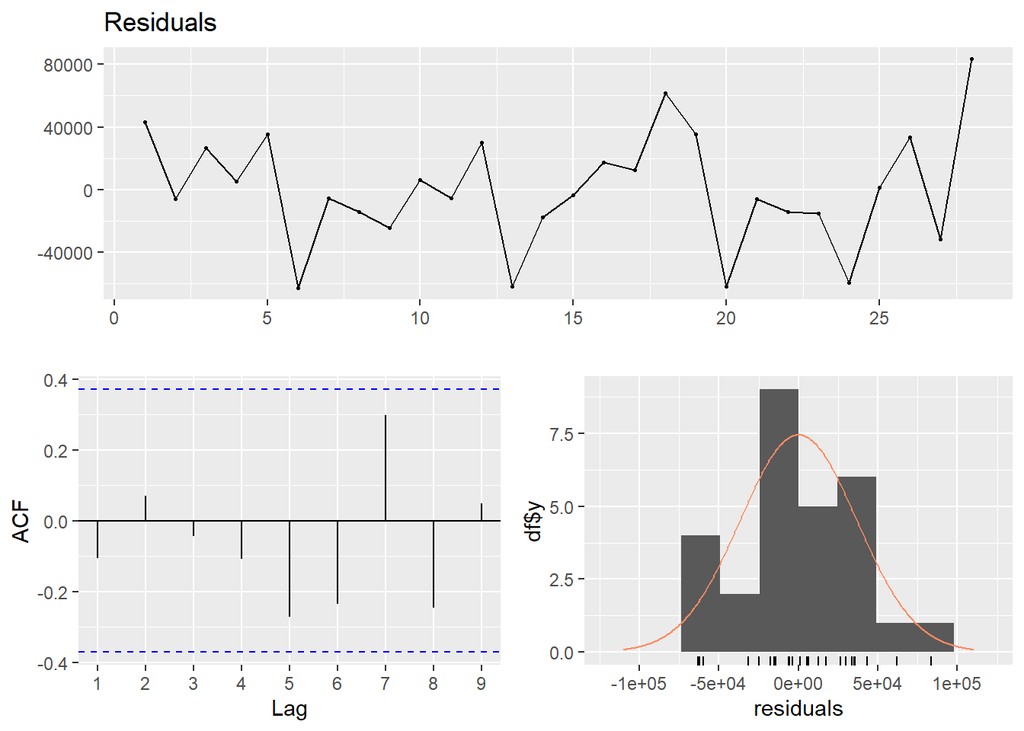

```r
checkresiduals(Model3$residuals)
```

```r
data$pred_model3[29:32]
```

```
## [1] 679198.6 787105.3 921839.8 730800.6
```

### Model 4

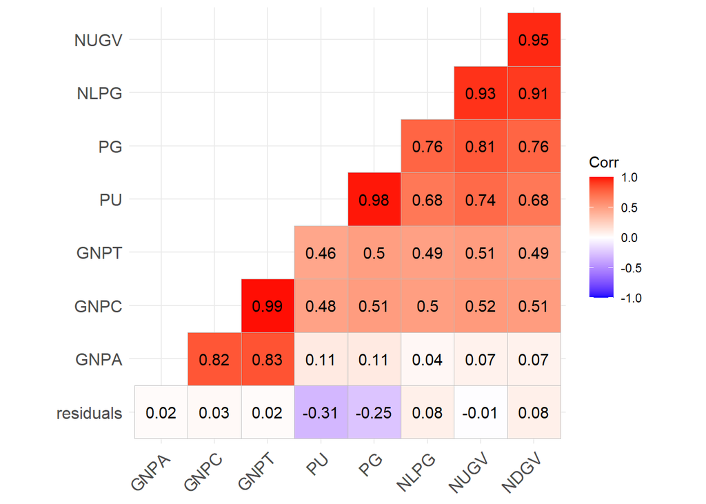

```r
# further improvements on model3
res_table[,residuals := c(Model3$residuals, rep(NA,4))]
res_table[,RNUV := NULL]

correl_info2=cor(res_table[1:28])

ggcorrplot(correl_info2,
           hc.order = TRUE,
           type = "lower",
           lab = TRUE)
```

The RNUV column is deleted and the residuals are updated respect to model3. Then, by looking correlation matrix and ggplots of residuals vs PU and PG, I choose second independent variable to use in the model as PG.

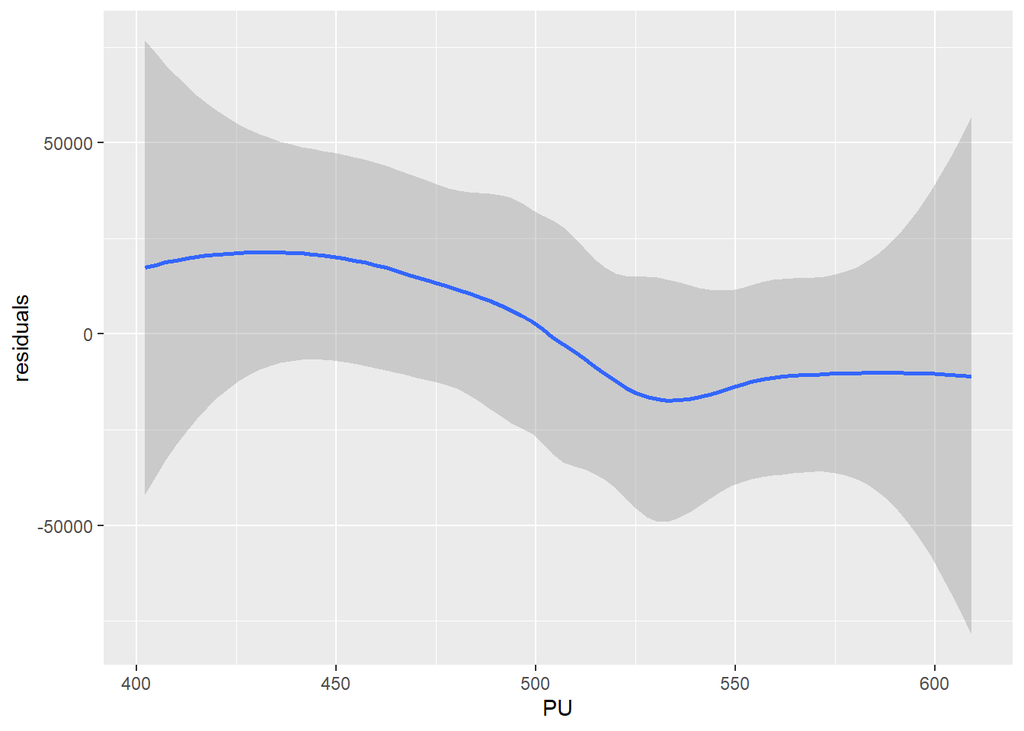

```r
ggplot(res_table,aes(x=PU, y=residuals)) + geom_smooth()
```

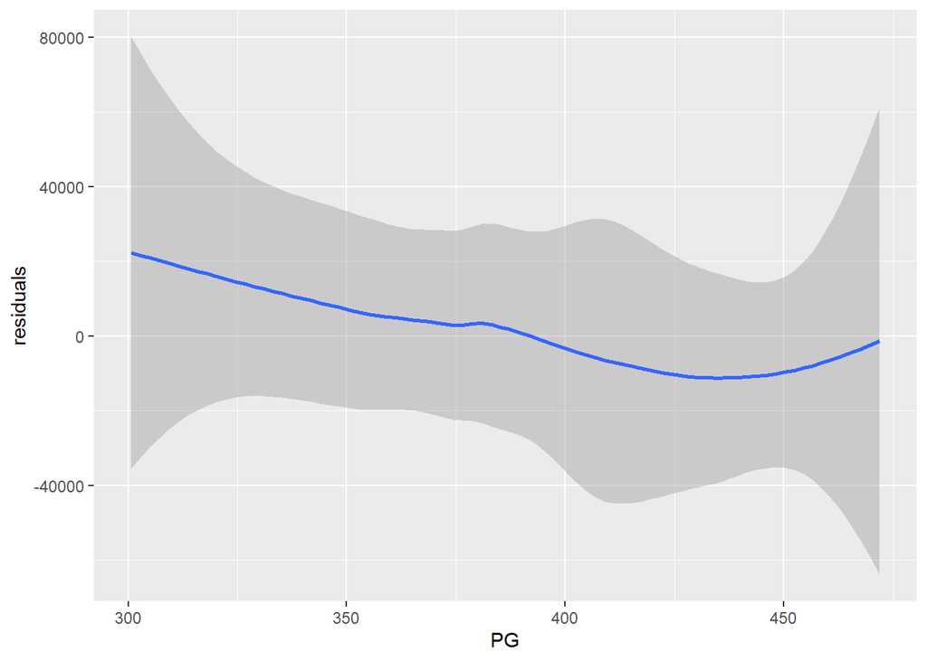

```r
ggplot(res_table,aes(x=PG, y=residuals)) + geom_smooth()
```

In the model summary, F-statistic, p-value and adjusted R-squared values prove that the model4 is strong enough. Also, the residuals are close to be random as seen in the results of checkresiduals() function.

```r
Model4 <- lm(UGS ~ trend + QuarterFactor + RNUV + PG, data)
summary(Model4)
```

```
##
## Call:
## lm(formula = UGS ~ trend + QuarterFactor + RNUV + PG, data = data)
##
## Residuals:
##    Min     1Q Median     3Q    Max
## -50391 -21986   -235  12099  81108
##
## Coefficients:
##                 Estimate Std. Error t value Pr(>|t|)
## (Intercept)    1240449.8    88857.8  13.960 4.27e-12 ***
## trend           -10135.0     1607.5  -6.305 2.98e-06 ***
## QuarterFactor2  109153.7    20203.4   5.403 2.33e-05 ***
## QuarterFactor3  263725.2    20521.4  12.851 2.04e-11 ***
## QuarterFactor4   63681.6    21295.0   2.990 0.006972 **
## RNUV           4943111.5  1259276.5   3.925 0.000776 ***
## PG                -657.2      275.1  -2.389 0.026350 *
## ---
## Signif. codes:  0 '***' 0.001 '**' 0.01 '*' 0.05 '.' 0.1 ' ' 1
##
## Residual standard error: 36950 on 21 degrees of freedom
##   (4 observations deleted due to missingness)
## Multiple R-squared:  0.9535, Adjusted R-squared:  0.9402
## F-statistic:  71.7 on 6 and 21 DF,  p-value: 6.778e-13
```

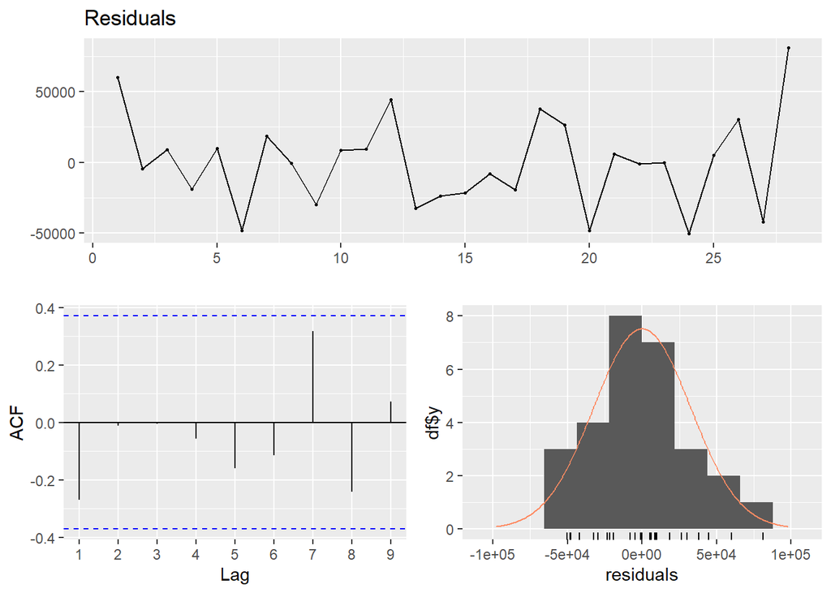

```r
checkresiduals(Model4$residuals)
```

### Prediction

Using the Model4, I forecast unleaded gasoline sales for 2007 (all quarters).

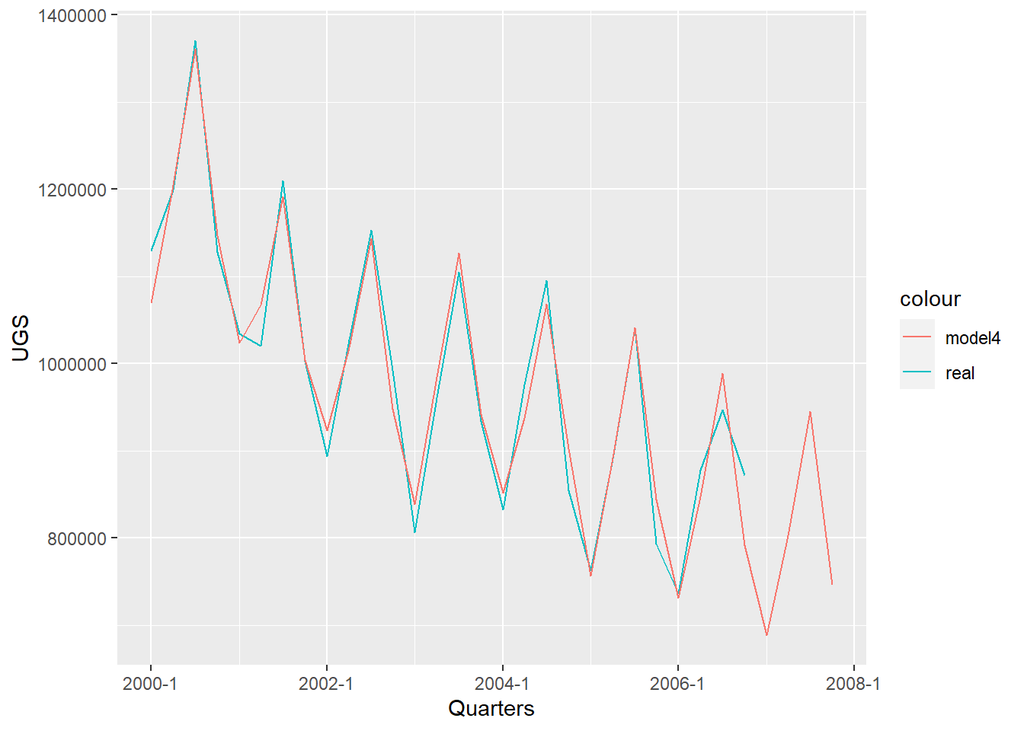

```r
data[,pred_model4 := predict(Model4,data)]
ggplot(data,aes(x=Quarters)) + geom_line(aes(y=UGS, color="real")) + geom_line(aes(y=pred_model4, color="model4"))
```

```r
prediction <- data.table()
prediction$Quarter <- data$Quarters[29:32]
prediction$prediction <- data$pred_model4[29:32]
prediction
```

```
##    Quarter prediction
## 1: 2007 Q1   687910.9
## 2: 2007 Q2   802747.6
## 3: 2007 Q3   944712.6
## 4: 2007 Q4   745903.2
```